# The ccex Package Vignette

Michael J. Kane

2017-04-05

# Introduction

Package ‘ccex’ is an R implementation of the REST interface used by the [C-Cex crypto-currency exchange](https://c-cex.com/). It provides functions for endpoints supported by the exchange. This includes the ability to retrieve price, volume, and orderbook information as well as the ability to trade crypto-currencies.

Calls to the exchange are categorized as either public, which includes requests for price, volume, and order book information, and private, which includes all requests requiring an account including placing buy or sell orders. Public calls can be used directly by installing the package. Private calls require that you [create an account](https://c-cex.com/?id=reg) and create an API and secret key with appropriate permissions.

# Installing the Package.

The package is available from GitHub and will be uploaded to CRAN shortly. If you wish to install the development version then install the [devtools package](https://CRAN.R-project.org/package=devtools), available from CRAN.

```r
#install.packages("devtools")
devtools::install_github("kaneplusplus/ccex")
```

# Using the Public Interface

The public interface to the exchange allows you to get market-level data including price, volume, and order book information. The following function are supported via the public interface:

- `coinnames`: coin names for all currencies
- `getballancedistribution`: exchange’s wallet balance distribution
- `getmarkethistory`: recent history for a market
- `getmarkets`: available markets and other meta-data
- `getmarketsummaries`: summary of active markets
- `getorderbook`: order book for a market
- `pairs`: available trading pairs
- `prices`: prices for all markets
- `volume`: volume of trades for a currency

Each of these functions returns a named list. The first element, `success`, is a boolean value indicating whether or not the function call was succesful. The second element, `message`, provides an error message if the call was not successful. The third element, `result` is the result of the function call.

The following sections provide simple examples using the `ccex` package with popular visualization and finance packages.

## Visualizing All Trading Pairs

There are currently 187 unique currencies listed on the exchange. However, this does not imply that there are ${187 \choose 2}=17391$ markets. Many of the currencies do not have the volume required for a viable market. To understand the structure of the available markets, we can use a graphical model to visualize which currencies may be traded. The following code creates the graph and creates an interactive visualization using Bryan Lewis’ `threejs` library. Note that the result graph supports “spinning” the graph as well as “zooming in” on vertices of interest.

```r
# Create a function to load libraries quietly.
shut_up = function(load_lib) {
  suppressWarnings(suppressPackageStartupMessages(load_lib))
}

# Load the libraries quietly.
shut_up(library(ccex))
shut_up(library(threejs))
shut_up(library(tidyverse))
shut_up(library(igraph))

# Create a graph of the crypo-currency markets.
currency_pairs = pairs()$result
currency_graph = currency_pairs %>% strsplit("-") %>% unlist %>%
  matrix(ncol=2, byrow=TRUE) %>% as.data.frame(stringsAsFactors=FALSE) %>%
  graph_from_data_frame
graphjs(currency_graph, vertex.size=0.5, vertex.label=V(currency_graph)$name, edge.width=0.25)
```

[interactive chart not shown]

The visualization shows that four currencies - btc, usd, ltc, and doge - act as a “hub.” Currencies that are “lightly” traded connect to one or more of the hub currencies. Trading between lightly traded currencies are performed by trading through hub currencies only.

## Visualizing Price Data with Quantmod

The public interface also supports the retrieval of traditional currency-market information, including price and volume data. The `getmarkethistory` extracts up through the last 100 transactions on a specified market. In this example, the price and volume of Bitcoin trades in U.S. dollars is turned into an `xts` time-series object and visualized using Jeffrey Ryan’s `quantmod` package.

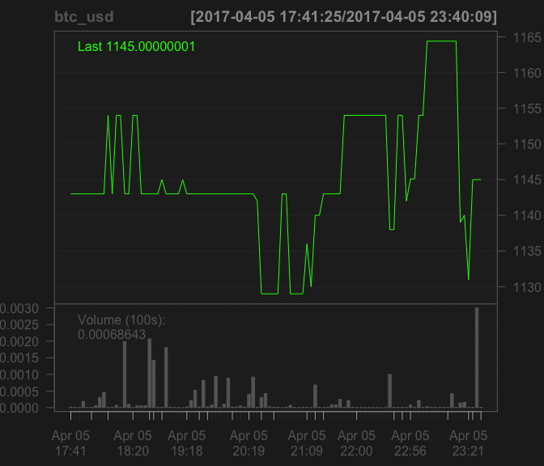

```r
shut_up(library(quantmod))

# Get the recent history of the usd-btc market.
btc_usd_df = getmarkethistory("btc-usd", 100)$result
btc_usd = btc_usd_df %>% select(price, quantity) %>%
  xts(order.by=btc_usd_df$time_stamp)
names(btc_usd)[2] = "volume"

# Chart the recent price history.
chartSeries(btc_usd)
```

The price of a Bitcoin, in U.S. dollars is shown in the top half of the graph. Changes in prices are associated with individuals buying (and selling) Bitcoins at a specified price. The number of Bitcoins bought (and sold) is shown in the bottom half of the graph.

## Visualizing the Order Book with ggplot2

The package also allows users to find orders for a given market. That is, the number of Bitcoins an individual would like to buy or sell along with the associated price he or she would like. A “buy” order is a request to buy a specified number of Bitcoins at a specified price and a sell is a request to sell Bitcoins with analogous constraints. The difference between the higest buy order and the lowest sell order is called the *spread*. The set of buy and sell orders is called the order book. The order book is visualized below using Hadley Wickam’s `ggplot2` package.

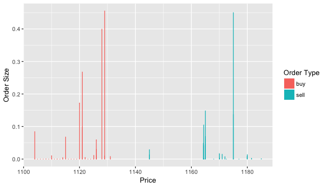

```r
# Create a data.frame frome the "buy" and "sell" orders.
btc_usd_req = getorderbook("btc-usd")$result
btc_usd_req$buy$type = "buy"
btc_usd_req$sell$type = "sell"
btc_usd = bind_rows(btc_usd_req$buy, btc_usd_req$sell)

# Plot the order book.
ggplot(btc_usd, aes(x=rate, y=quantity, group=type, color=type, fill=type)) +
  geom_bar(stat="identity") + xlab("Price") +
  ylab("Order Size") + scale_fill_discrete(name = "Order Type") +
  scale_color_discrete(guide=FALSE)
```

# Using the Private Interface

**Diclaimer:** This software is in no way affiliated, endorsed, or approved by the [C-Cex crypto-currency exchange](https://c-cex.com/) or any of its affiliates. It comes with absolutely no warranty and should not be used in actual trading unless the user can read and understand the source and know what you are doing.

The private interface allows users to trade in crypto-currencies on the exchange. Private calls require that you [create an account](https://c-cex.com/?id=reg) and create an API and secret key with appropriate permissions. These keys allow the user to successfully call the following functions:

- `buylimit`: place a buy limit order
- `cancel`: cancel an open order
- `ccex_authenticate`: provide user authentication data
- `getbalance`: account balance for a specified currency
- `getblanances`: account balances for currencies
- `getopenorders`: order data for all open orders
- `getorderdata`: order data for a specified order
- `getorderhistory`: recent order history for an account
- `mytrades`: detailed recent trading history for a market
- `selllimit`: place a sell limit order

Private calls retrieve the API and secret key using the CCEX_API_KEY and CCEX_SECRET_KEY environment variables. These may be set by the user before opening the R session or, they can be set using the ‘ccex_authenticate’ function.